# Lab 3

### Example for stl()

STL applied to the electrical equipment orders data.

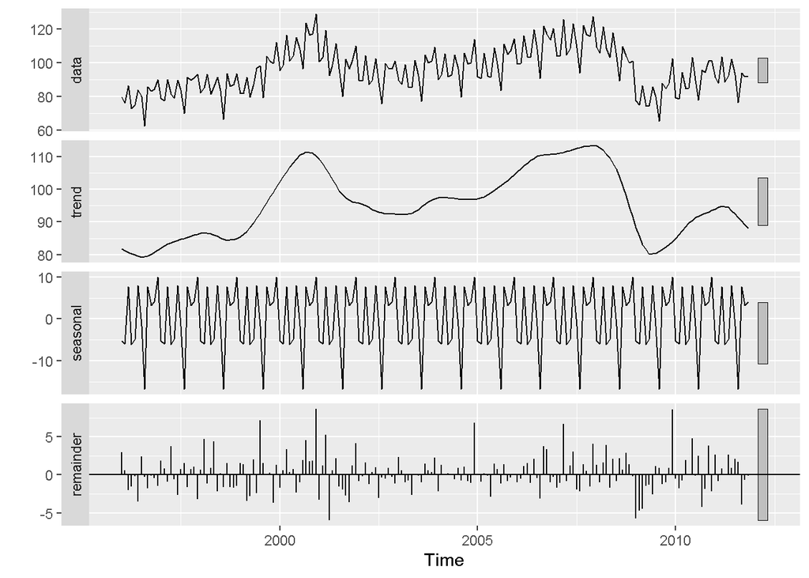

```r
elecequip %>%
  stl(t.window=13, s.window="periodic", robust=TRUE) %>%
  autoplot()
```

Here, it is more obvious that there has been a down-turn at the end of the series, and that the orders in 2009 were unusually low (corresponding to some large negative values in the remainder component).

The user must specify *s.window* as there is no default. Setting it to be infinite is equivalent to forcing the seasonal component to be periodic (i.e., identical across years).

### Conclusion:

** Decomposition is often used to remove the seasonal effect from a time series.

** It provides a cleaner way to understand trends. For instance, lower ice cream sales during winter don’t necessarily mean a company is performing poorly.

** To know whether or not this is the case, we need to remove the seasonality from the time series.

** We also use the random (also call remainder) time series from the decomposed time series to detect anomalies and outliers.

# White Noise

A particularly useful white noise series is Gaussian white noise, wherein the $w_t$ are independent normal random variables, with mean 0 and variance $\sigma ^2_w$ ; or more succinctly,
$$wt \sim iid N(0, \sigma ^2_w)$$

White noise is an important concept in time series analysis and forecasting.

It is important for two main reasons:

1. Predictability: If your time series is white noise, then, by definition, it is random. You cannot reasonably model it and make predictions.
2. Model Diagnostics: The series of errors from a time series forecast model should ideally be white noise. Why?  
   When forecast errors are white noise, it means that all of the signal information in the time series has been harnessed by the model in order to make predictions. All that is left is the random fluctuations that cannot be modeled.

A sign that model predictions are not white noise is an indication that further improvements to the forecast model may be possible.

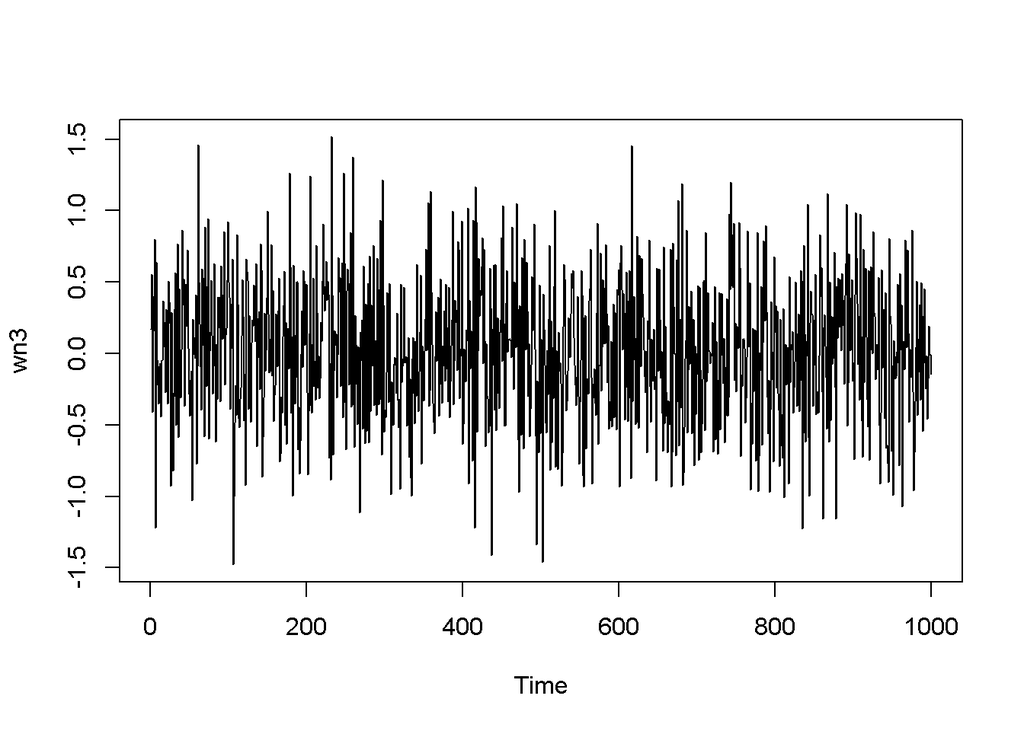

```r
wn3=rnorm(1000, 0, 0.5)

plot.ts(wn3)
```

# ACF & PACF

The function ACF computes (and by default plots) an estimate of the autocorrelation function of a univariate time series. Function PACF computes (and by default plots) an estimate of the partial autocorrelation function of a univariate time series.

Autocorrelation and partial autocorrelation plots are heavily used in time series analysis and forecasting.

ACF is an (complete) auto-correlation function which gives us values of auto-correlation of any series with its lagged values. We plot these values along with the confidence band and tada! We have an ACF plot. In simple terms, it describes how well the present value of the series is related with its past values. A time series can have components like trend, seasonality, cyclic and residual. ACF considers all these components while finding correlations hence it’s a ‘complete auto-correlation plot’.

PACF is a partial auto-correlation function. Basically instead of finding correlations of present with lags like ACF, it finds correlation of the residuals (which remains after removing the effects which are already explained by the earlier lag(s)) with the next lag value hence ‘partial’ and not ‘complete’ as we remove already found variations before we find the next correlation. So if there is any hidden information in the residual which can be modeled by the next lag, we might get a good correlation and we will keep that next lag as a feature while modeling. Remember while modeling we don’t want to keep too many features which are correlated as that can create multicollinearity issues. Hence we need to retain only the relevant features.

```r
library(astsa)
library(xts)
```

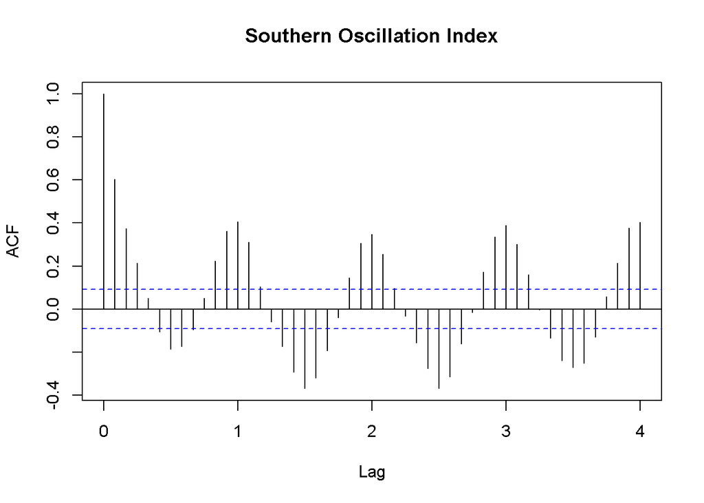

```r
acf(soi, 48, main="Southern Oscillation Index")
```

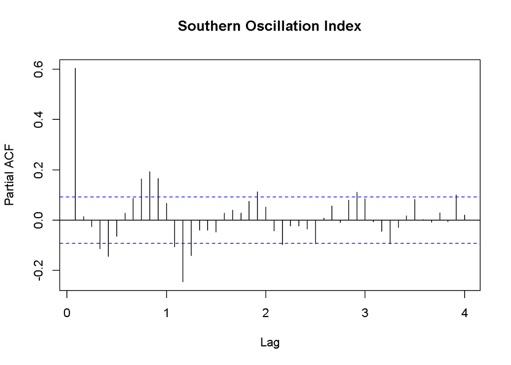

```r
pacf(soi, 48, main="Southern Oscillation Index")
```

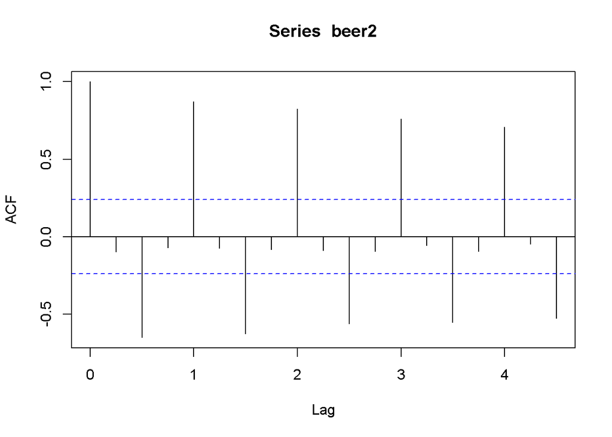

```r
acf(beer2)
```

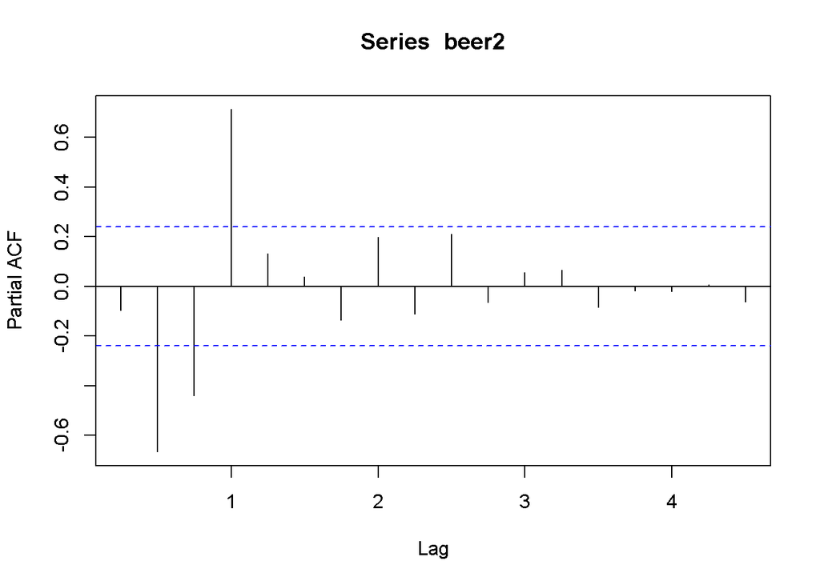

```r
pacf(beer2)
```

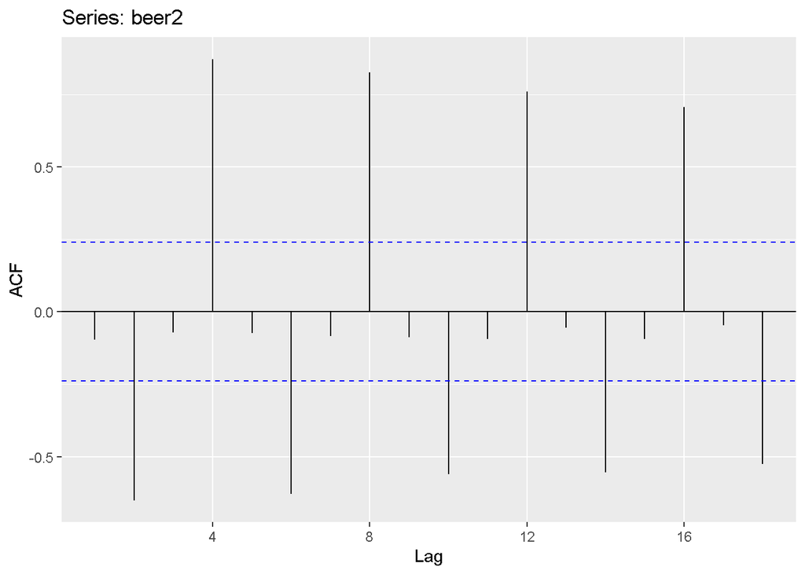

```r
ggAcf(beer2)
```

By looking at the ACF, it can be concluded that the series is not Stationary.

In this graph:

$r_4$ is higher than for the other lags. This is due to the seasonal pattern in the data: the peaks tend to be four quarters apart and the troughs tend to be four quarters apart.

$r_2$ is more negative than for the other lags because troughs tend to be two quarters behind peaks.

The dashed blue lines indicate whether the correlations are significantly different from zero.

# Stationary

## Augmented Dickey-Fuller Test to check the stationarity

A time series of the numbers of users connected to the Internet through a server every minute.

```r
df.ts=WWWusage
str(df.ts)
```

```
##  Time-Series [1:100] from 1 to 100: 88 84 85 85 84 85 83 85 88 89 ...
```

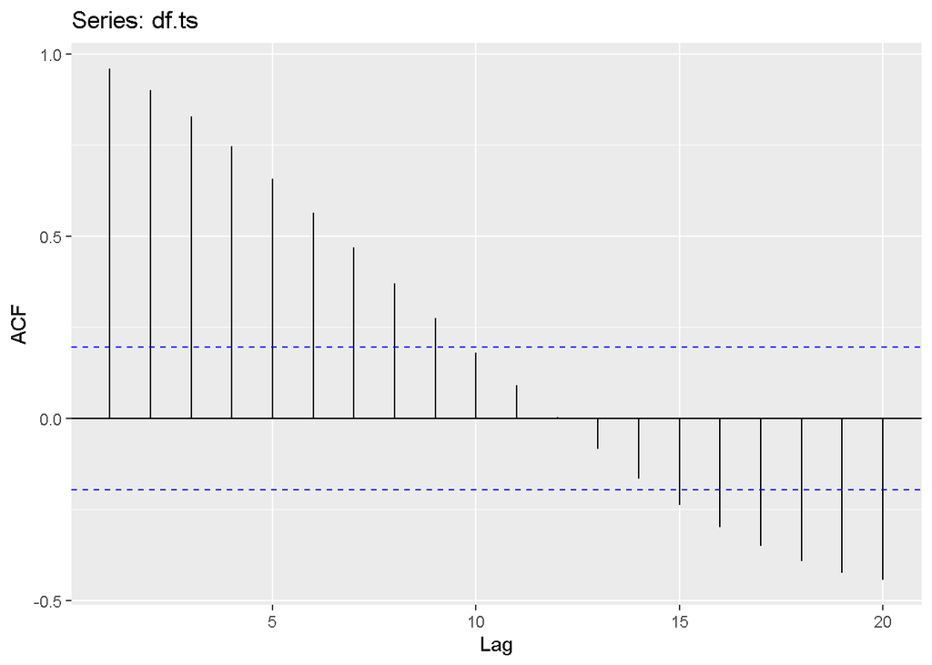

```r
ggAcf(df.ts)
```

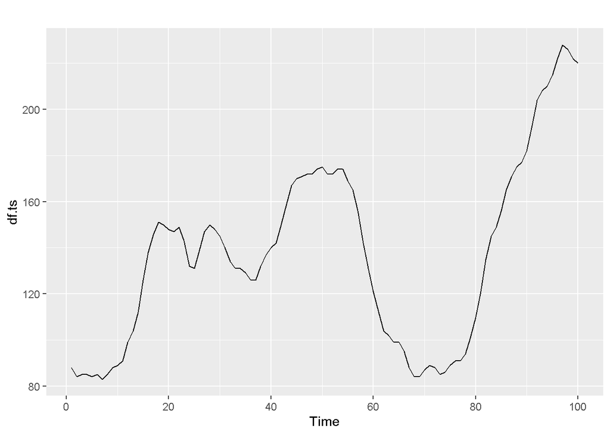

```r
autoplot(df.ts)
```

```r
tseries::adf.test(df.ts)
```

```
##
##  Augmented Dickey-Fuller Test
##
## data:  df.ts
## Dickey-Fuller = -2.6421, Lag order = 4, p-value = 0.3107
## alternative hypothesis: stationary
```

P-value is greater than 0.05. So obviously the series in not stationary.

## Force nonstationary data to stationarity:

### Detrending Data

Differencing is generally good for removing trend from time series data. (Recall that differencing looks at the difference between the value of a time series at a certain point in time and its preceding value.)

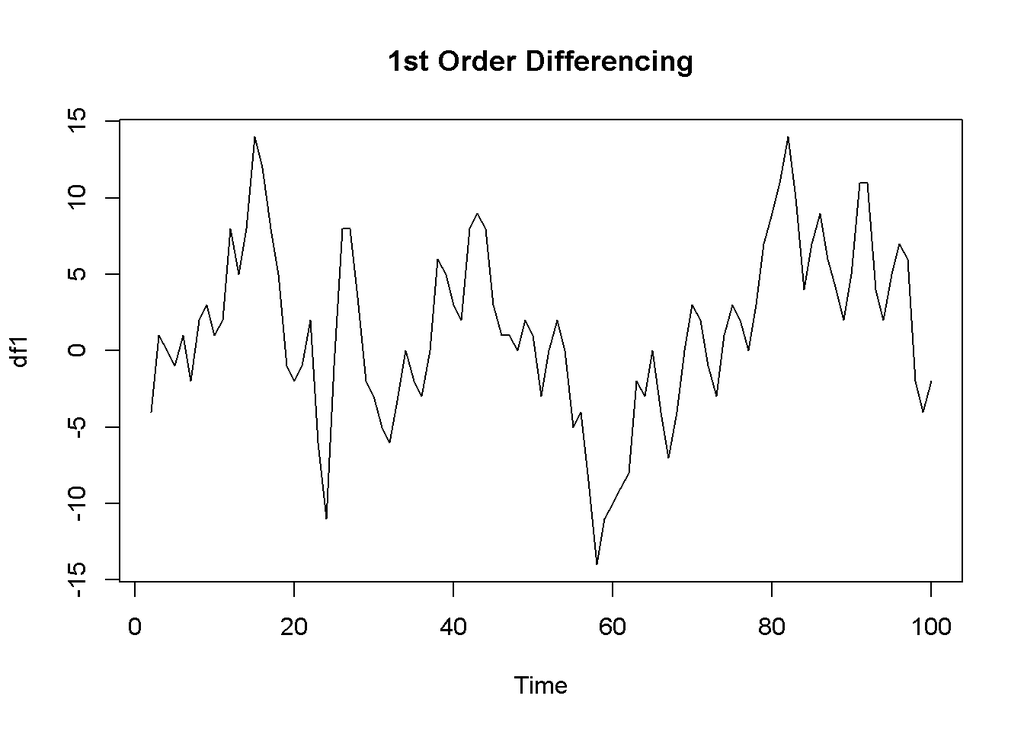

```r
df1=diff(df.ts)
df2=diff(diff(df.ts))
plot(df1, main ="1st Order Differencing")
```

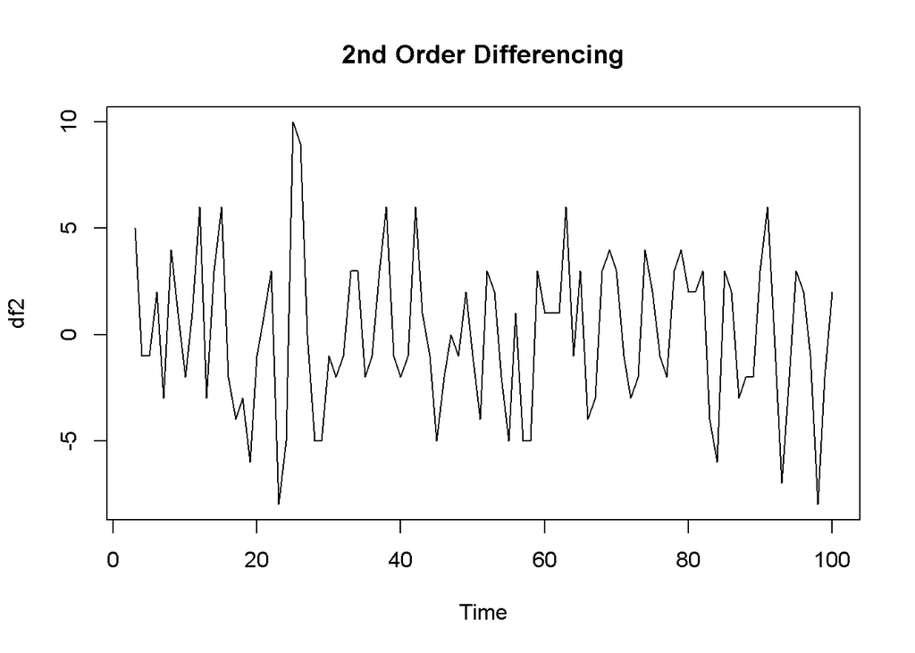

```r
plot(df2, main = "2nd Order Differencing")
```

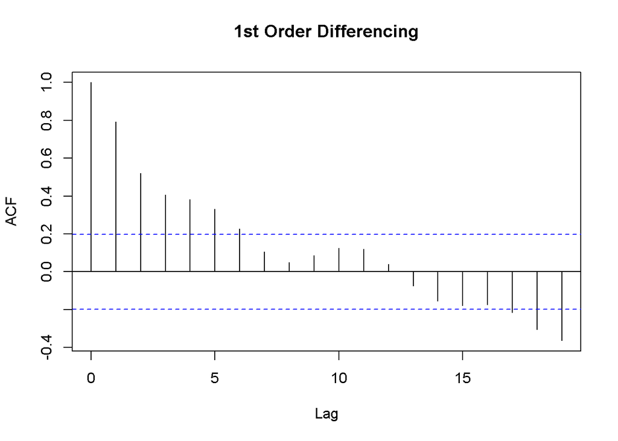

```r
acf(df1, main ="1st Order Differencing")
```

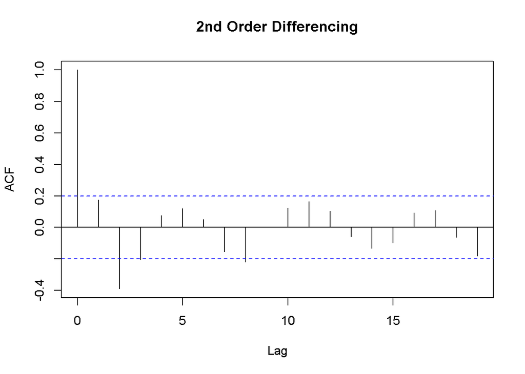

```r
acf(df2, main = "2nd Order Differencing")
```

• Generate a multifigure plot comparing the global temperature data (globtemp) with the detrended series. You can create a multifigure plot by running the pre-written par() command followed by two separate calls to plot().

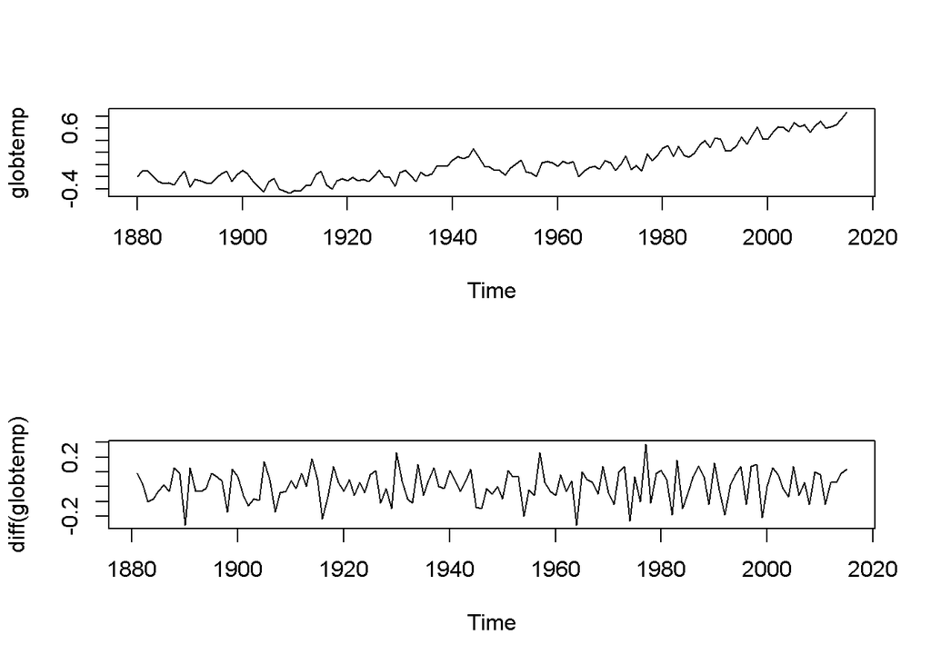

```r
# Plot globtemp and detrended globtemp
par(mfrow = c(2,1))
plot(globtemp)

plot(diff(globtemp))
```

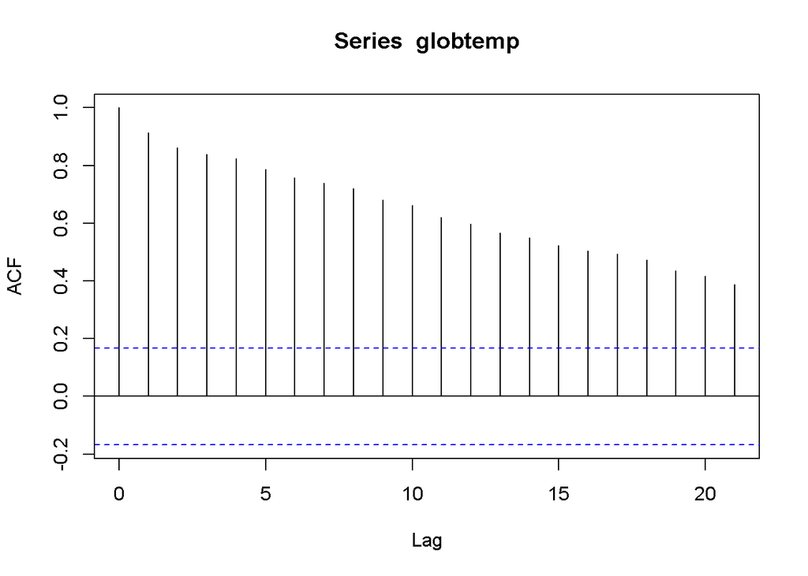

```r
acf(globtemp)
```

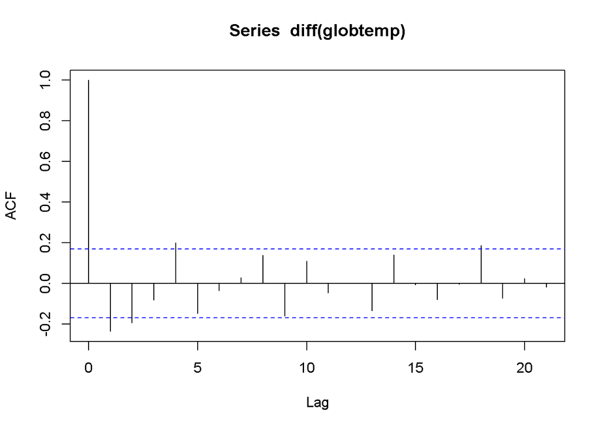

```r
acf(diff(globtemp))
```

• Generate another multifigure plot comparing the weekly cardiovascular mortality in Los Angeles County (cmort) with the detrended series.

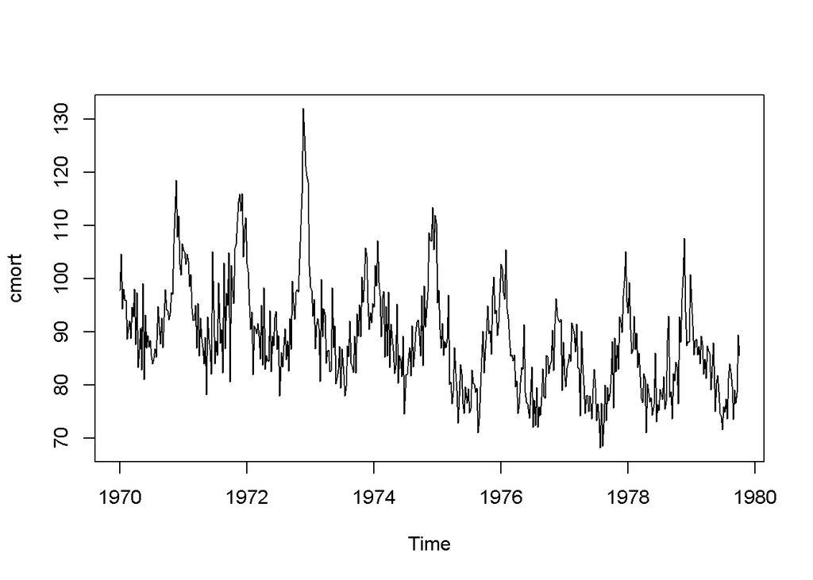

```r
# Plot cmort and detrended cmort
#par(mfrow = c(2,1))
plot(cmort)
```

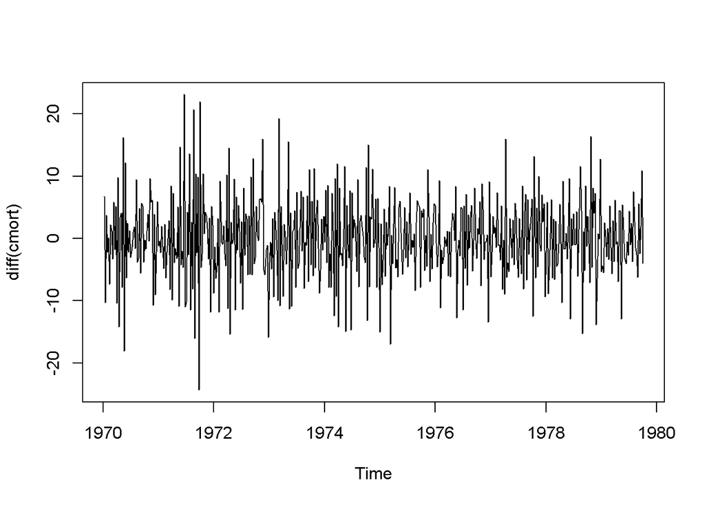

```r
plot(diff(cmort))
```

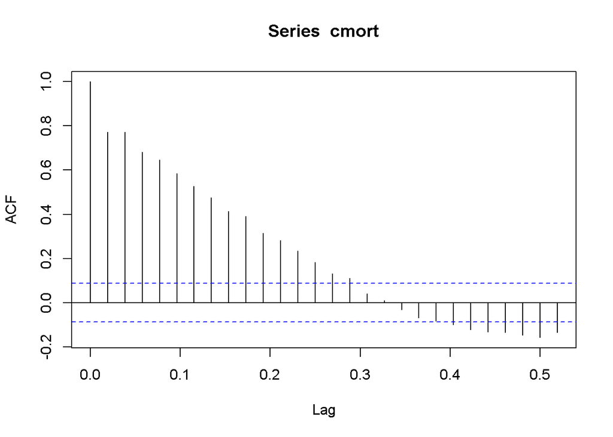

```r
acf(cmort)
```

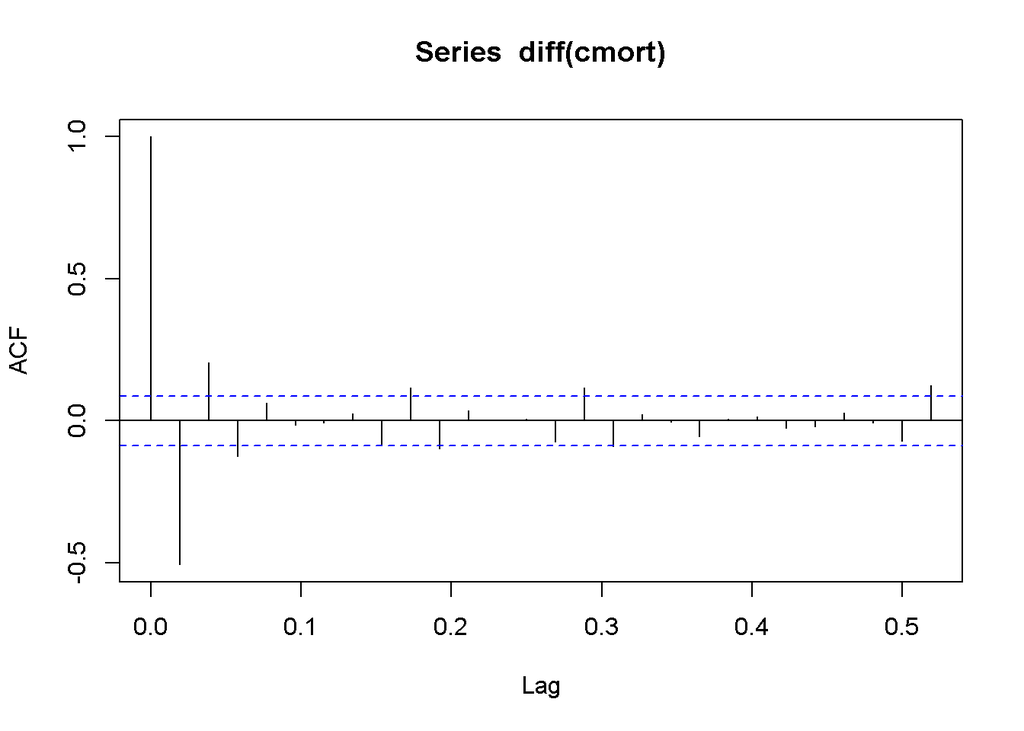

```r
acf(diff(cmort))
```

Generate a multifigure plot to (1) plot the quarterly US GNP (gnp) data and notice it is not stationary, and (2) plot the approximate growth rate of the US GNP using diff() and log().

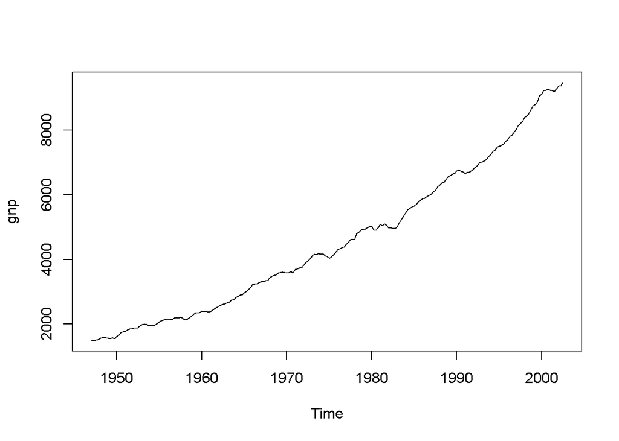

```r
# Plot GNP series (gnp) and its growth rate
#par(mfrow = c(2,1))
plot(gnp)
```

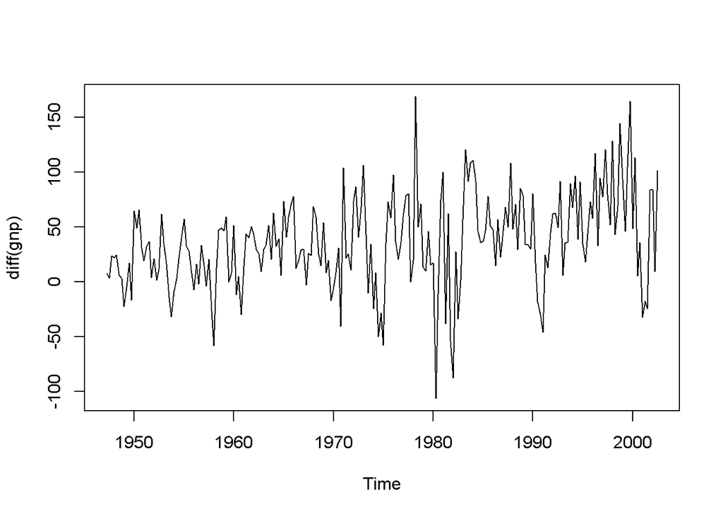

```r
plot(diff(gnp))
```

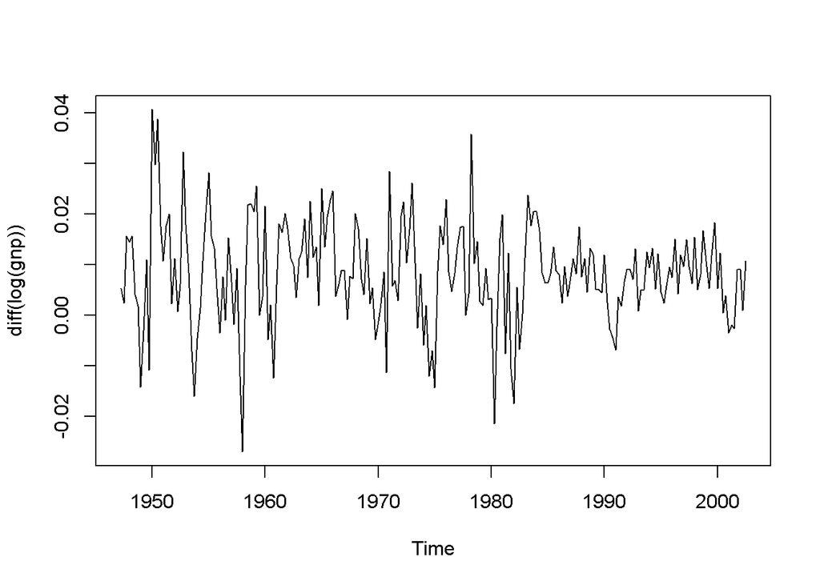

```r
plot(diff(log(gnp)))
```

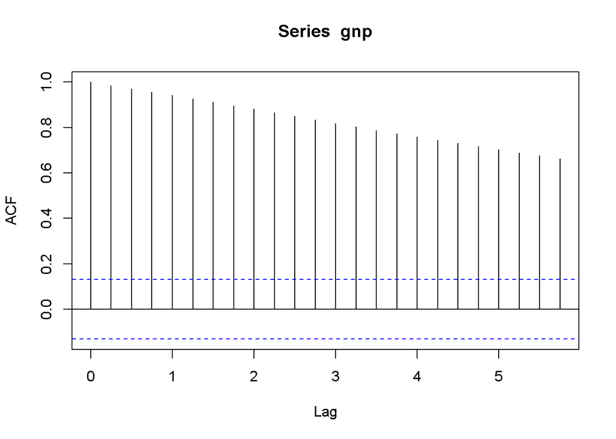

```r
acf(gnp)
```

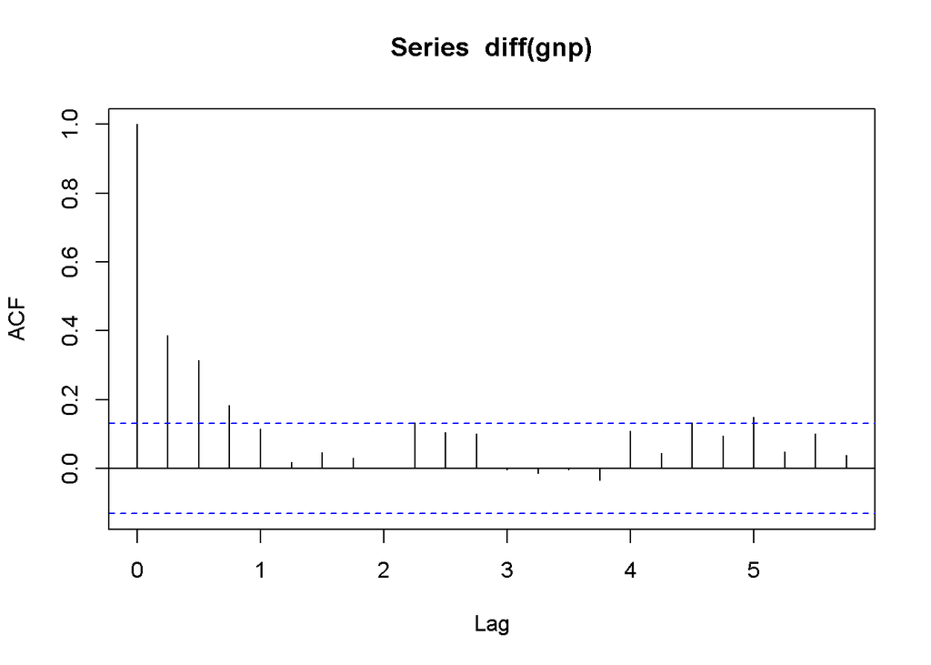

```r
acf(diff(gnp))
```

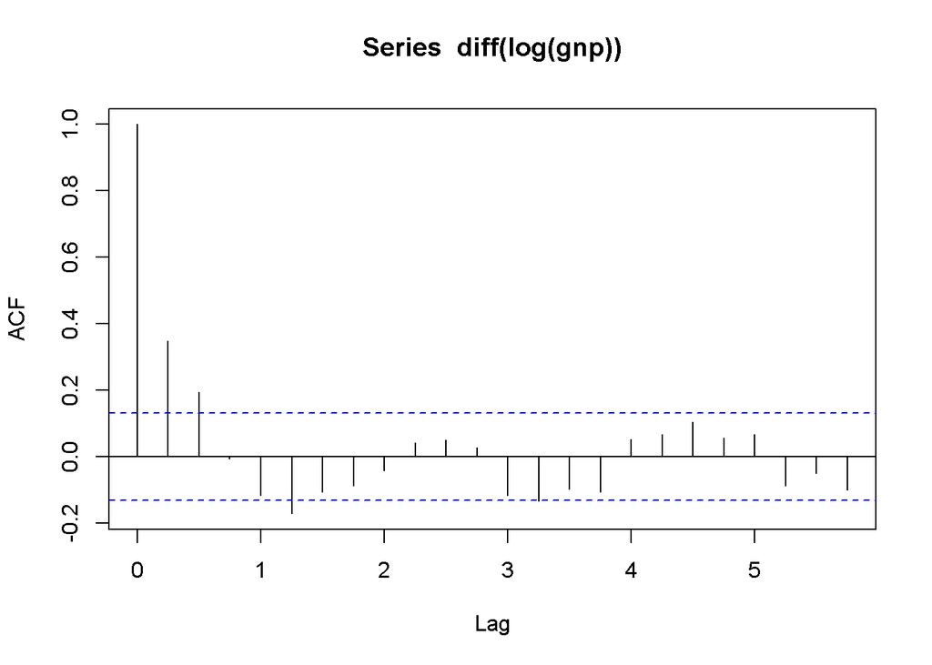

```r
acf(diff(log(gnp)))
```

• Use a multifigure plot to (1) plot the daily DJIA closings (djia$Close) and notice that it is not stationary. The data are an xts object. Then (2) plot the approximate DJIA returns using diff() and log(). How does this compare to the growth rate of the GNP?

log(): is used to remove the hetroscadastisity.

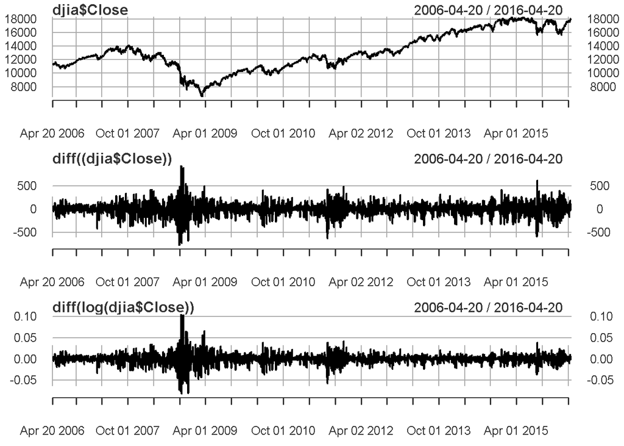

```r
# Plot DJIA closings (djia$Close) and its returns
par(mfrow = c(3,1))
plot(djia$Close)
plot(diff((djia$Close)))
plot(diff(log(djia$Close)))
```

```r
str(djia$Close)
```

```
## An 'xts' object on 2006-04-20/2016-04-20 containing:
##   Data: num [1:2518, 1] 11343 11347 11336 11283 11354 ...
##  - attr(*, "dimnames")=List of 2
##   ..$ : NULL
##   ..$ : chr "Close"
##   Indexed by objects of class: [Date] TZ: UTC
##   xts Attributes:
##  NULL
```

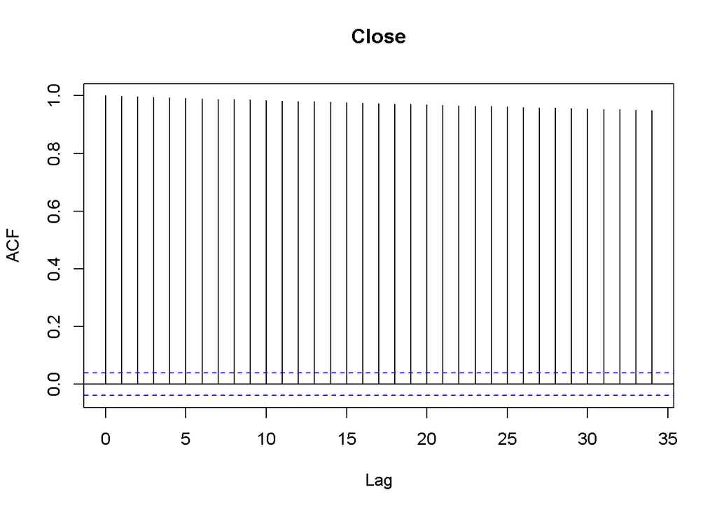

```r
acf(ts(djia$Close))
```

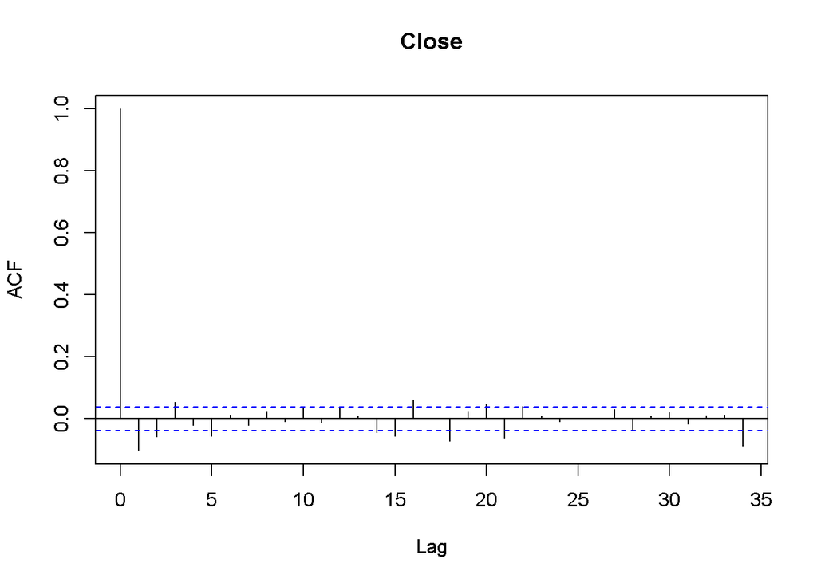

```r
acf(diff(log(ts(djia$Close))))
```